# Test Social Assay Analysis

Alexa & Viktoria & Adam

April 6, 2019

Load libraries

```r
# tidyverse includes the packages readr, dplyr, ggPlot ... etc.
library(tidyverse)

# ggbeeswarm includes geom_beeswarm()
library(ggbeeswarm)

# broom includes tidy()
library(broom)

# ggplots
library(ggplot2)

# ggpubr for paired ggplots
library(ggpubr)
```

## Read in the raw data

Read in the social test raw data (**Analysis Output-AV Social Duration.csv**):

```r
# Import social data
socialRaw <- read_csv("Analysis Output-AV Social Duration.csv", skip = 4,
                            col_names = header)
# Look at social data
socialRaw
```

```
## # A tibble: 38 x 13
##    Trial   Sex Treatment Tag   `Animal Presenc~ `Distance moved~
##    <dbl> <dbl>     <dbl> <chr>            <dbl>            <dbl>
##  1     1     0         0 F1R                  0            2437.
##  2     2     0         0 F1R                  1            1770.
##  3     3     0         1 F2R                  0            1832.
##  4     4     0         1 F2R                  1            1313.
##  5     5     0         0 F3R                  0            1688.
##  6     6     0         0 F3R                  1             875.
##  7     7     0         0 F2L                  0            1855.
##  8     8     0         0 F2L                  1            1508.
##  9     9     0         1 F3L                  0            1441.
## 10    10     0         1 F3L                  1            1274.
## # ... with 28 more rows, and 7 more variables: `In zone:object 1 boundary
## #   zone/Nose-point:Duration` <dbl>, `In zone_1:object 1 boundary
## #   zone/Nose-point:Frequency` <dbl>, `In zone_2:object 1 boundary
## #   zone/Nose-point:Latency to first` <dbl>, `In zone_3:object 1 boundary
## #   zone/Center-point:Duration` <dbl>, `In zone_4:object 1 boundary
## #   zone/Center-point:Frequency` <dbl>, `In zone_5:object 1 boundary
## #   zone/Center-point:Latency to first` <dbl>,
## #   `Velocity/Center-point:Mean` <dbl>
```

Read in the data containing the treatment and sex information for each animal (**Social Injections Data.csv**):

```r
# Import injections data
socialInjectionsDataRaw <- read_csv("Social Injections Data.csv", n_max = 20)
# Take a look at the social injections data
socialInjectionsDataRaw
```

```
## # A tibble: 20 x 28
##      Sex Treatment `Cage1:ID` `Weight (g) 02/~ `02/09` `02/10` `02/11`
##    <dbl>     <dbl> <chr>                 <dbl>   <dbl>   <dbl>   <dbl>
##  1     0         1 1L                       24      28      32      35
##  2     0         0 2L                       25      29      31      34
##  3     0         1 3L                       26      29      32      34
##  4     0         0 1R                       29      32      35      39
##  5     0         1 2R                       28      32      36      38
##  6     0         0 3R                       25      29      31      35
##  7     0         1 1L, 1R                   24      27      30      33
##  8     0         0 1L, 2R                   25      27      30      33
##  9     0         1 2L, 1R                   27      30      34      39
## 10     0         0 2L, 2R                   23      25      28      30
## 11     1         1 1L                       25      27      30      33
## 12     1         0 2L                       27      30      32      35
## 13     1         1 3L                       29      31      34      38
## 14     1         0 1R                       27      30      33      37
## 15     1         1 2R                       25      28      29      32
## 16     1         0 3R                       28      30      32      36
## 17     1         1 1L, 1R                   30      32      34      36
## 18     1         0 1L, 2R                   28      31      34      37
## 19     1         1 2L, 1R                   26      29      30      34
## 20     1         0 2L, 2R                   28      32      33      35
## # ... with 21 more variables: `02/12` <dbl>, `02/13` <chr>, `02/14` <dbl>,
## #   `02/15` <dbl>, `02/16` <dbl>, `02/17` <dbl>, `02/18` <dbl>,
## #   `02/19` <dbl>, `02/20` <dbl>, `02/21` <dbl>, `02/22` <dbl>,
## #   `02/23` <dbl>, `02/24` <dbl>, `2/25/2019 (construction noises)` <dbl>,
## #   `02/26` <dbl>, `02/27` <dbl>, `02/28` <chr>, Cage <dbl>, `Animal
## #   Absent Trial` <dbl>, `Animal Present Trial` <dbl>, X28 <lgl>
```

Read in a table that maps treatment numbers to treatment strings

```r
# Create a dictionary for Treatment
treatmentTypeTable <- read_csv("Treatment Dictionary.csv")

# Display the table
treatmentTypeTable
```

```
## # A tibble: 2 x 2
##   Treatment TreatmentStr
##       <dbl> <chr>
## 1         0 Control
## 2         1 Ethosuximide
```

```r
# Create a dictionary for Animal Presence
animalPresenceTypeTable <- read_csv("Animal Presence Dictionary.csv")

# Display the table
animalPresenceTypeTable
```

```
## # A tibble: 2 x 2
##   `Animal Presence` PresenceStr
##               <dbl> <chr>
## 1                 0 Animal Absent
## 2                 1 Animal Present
```

## Combine and rearrange the data

Starting from the Social raw data, do the following: (TODO: UPDATE)  
1. Combine treatment information  
2. Add the treatment string be matching up the treatment number  
3. Choose the column corresponding to duration with nose point and rename it  
4. Choose the column corresponding to duration with center point and rename it  
5. Make “TreatmentStr” a categorical variable 6. Make “PresenceStr” a categorical variable 7. Compute the “AnimalIsPresent” variable 8. Compute the “AnimalINotPresent” variable 9. Rename “Animal Presence” as “TrialType”  
10. Create a “TrialTypeTreatment” variable that combines “TreatmentStr” and “TrialType”

```r
# Rearrange the data
socialExpanded <-
    socialRaw %>%
    full_join(treatmentTypeTable, by = "Treatment")  %>%
    full_join(animalPresenceTypeTable, by = "Animal Presence")  %>%
    mutate(DurationNosePoint = `In zone:object 1 boundary zone/Nose-point:Duration`) %>%
    mutate(DurationCenterPoint = `In zone_3:object 1 boundary zone/Center-point:Duration`) %>%
    mutate(TreatmentStr = factor(TreatmentStr)) %>%
    mutate(PresenceStr = factor(PresenceStr)) %>%
    mutate(AnimalIsPresent = `Animal Presence`) %>%
    mutate(AnimalIsNotPresent = 1 - `Animal Presence`) %>%
    mutate(TrialType = factor(`Animal Presence`))  %>%
    mutate(TrialTypeTreatment = interaction(TreatmentStr, TrialType, sep = "-"))


# Take a glimpse of all the variables in the data
glimpse(socialExpanded)
```

```
## Observations: 38
## Variables: 21
## $ Trial                                                            <dbl> ...
## $ Sex                                                              <dbl> ...
## $ Treatment                                                        <dbl> ...
## $ Tag                                                              <chr> ...
## $ `Animal Presence`                                                <dbl> ...
## $ `Distance moved:Center-point`                                    <dbl> ...
## $ `In zone:object 1 boundary zone/Nose-point:Duration`             <dbl> ...
## $ `In zone_1:object 1 boundary zone/Nose-point:Frequency`          <dbl> ...
## $ `In zone_2:object 1 boundary zone/Nose-point:Latency to first`   <dbl> ...
## $ `In zone_3:object 1 boundary zone/Center-point:Duration`         <dbl> ...
## $ `In zone_4:object 1 boundary zone/Center-point:Frequency`        <dbl> ...
## $ `In zone_5:object 1 boundary zone/Center-point:Latency to first` <dbl> ...
## $ `Velocity/Center-point:Mean`                                     <dbl> ...
## $ TreatmentStr                                                     <fct> ...
## $ PresenceStr                                                      <fct> ...
## $ DurationNosePoint                                                <dbl> ...
## $ DurationCenterPoint                                              <dbl> ...
## $ AnimalIsPresent                                                  <dbl> ...
## $ AnimalIsNotPresent                                               <dbl> ...
## $ TrialType                                                        <fct> ...
## $ TrialTypeTreatment                                               <fct> ...
```

Remove the 26th animal because he interacted with the novel animal:

```r
# Select all but the 26th row
socialFiltered <-
     socialExpanded %>% filter(Trial != 25, Trial != 26)


# Take a look at the data with rows filter
socialFiltered
```

```
## # A tibble: 36 x 21
##    Trial   Sex Treatment Tag   `Animal Presenc~ `Distance moved~
##    <dbl> <dbl>     <dbl> <chr>            <dbl>            <dbl>
##  1     1     0         0 F1R                  0            2437.
##  2     2     0         0 F1R                  1            1770.
##  3     3     0         1 F2R                  0            1832.
##  4     4     0         1 F2R                  1            1313.
##  5     5     0         0 F3R                  0            1688.
##  6     6     0         0 F3R                  1             875.
##  7     7     0         0 F2L                  0            1855.
##  8     8     0         0 F2L                  1            1508.
##  9     9     0         1 F3L                  0            1441.
## 10    10     0         1 F3L                  1            1274.
## # ... with 26 more rows, and 15 more variables: `In zone:object 1 boundary
## #   zone/Nose-point:Duration` <dbl>, `In zone_1:object 1 boundary
## #   zone/Nose-point:Frequency` <dbl>, `In zone_2:object 1 boundary
## #   zone/Nose-point:Latency to first` <dbl>, `In zone_3:object 1 boundary
## #   zone/Center-point:Duration` <dbl>, `In zone_4:object 1 boundary
## #   zone/Center-point:Frequency` <dbl>, `In zone_5:object 1 boundary
## #   zone/Center-point:Latency to first` <dbl>,
## #   `Velocity/Center-point:Mean` <dbl>, TreatmentStr <fct>,
## #   PresenceStr <fct>, DurationNosePoint <dbl>, DurationCenterPoint <dbl>,
## #   AnimalIsPresent <dbl>, AnimalIsNotPresent <dbl>, TrialType <fct>,
## #   TrialTypeTreatment <fct>
```

```r
# Compute a duration ratio
socialSummarized <-
    socialFiltered %>%
    group_by(Tag, TreatmentStr) %>%
    summarise(DurationRatio = sum(DurationNosePoint * AnimalIsPresent) /
                sum(DurationNosePoint * AnimalIsNotPresent)) %>%
    mutate(Direction = if (DurationRatio > 1) "Increased" else "Decreased")

# Take a look at the duration ratio data
socialSummarized
```

```
## # A tibble: 18 x 4
## # Groups:   Tag [18]
##    Tag     TreatmentStr DurationRatio Direction
##    <chr>   <fct>                <dbl> <chr>
##  1 F1L     Ethosuximide         1.06  Increased
##  2 F1L, 1R Ethosuximide         2.20  Increased
##  3 F1L, 2R Control              1.43  Increased
##  4 F1R     Control              1.82  Increased
##  5 F2L     Control              1.96  Increased
##  6 F2L, 1R Ethosuximide         2.78  Increased
##  7 F2L, 2R Control              3.08  Increased
##  8 F2R     Ethosuximide         3.12  Increased
##  9 F3L     Ethosuximide         0.996 Decreased
## 10 F3R     Control              2.41  Increased
## 11 M1L     Ethosuximide         1.72  Increased
## 12 M1L, 1R Ethosuximide         0.695 Decreased
## 13 M1L, 2R Control              0.335 Decreased
## 14 M2L     Control              1.83  Increased
## 15 M2L, 1R Ethosuximide         0.733 Decreased
## 16 M2R     Ethosuximide         2.37  Increased
## 17 M3L     Ethosuximide         2.14  Increased
## 18 M3R     Control              1.82  Increased
```

Select only the variables that will be analyzed:

```r
# Select variables that will be analyzed
socialData <-
    socialFiltered %>%
    select(Trial, TrialType, Treatment = TreatmentStr, `Animal Presence`, PresenceStr, Sex,
           DurationNosePoint, DurationCenterPoint, Tag, TrialTypeTreatment)

# Take a look at the data with columns filtered
socialData
```

```
## # A tibble: 36 x 10
##    Trial TrialType Treatment `Animal Presenc~ PresenceStr   Sex
##    <dbl> <fct>     <fct>                <dbl> <fct>       <dbl>
##  1     1 0         Control                  0 Animal Abs~     0
##  2     2 1         Control                  1 Animal Pre~     0
##  3     3 0         Ethosuxi~                0 Animal Abs~     0
##  4     4 1         Ethosuxi~                1 Animal Pre~     0
##  5     5 0         Control                  0 Animal Abs~     0
##  6     6 1         Control                  1 Animal Pre~     0
##  7     7 0         Control                  0 Animal Abs~     0
##  8     8 1         Control                  1 Animal Pre~     0
##  9     9 0         Ethosuxi~                0 Animal Abs~     0
## 10    10 1         Ethosuxi~                1 Animal Pre~     0
## # ... with 26 more rows, and 4 more variables: DurationNosePoint <dbl>,
## #   DurationCenterPoint <dbl>, Tag <chr>, TrialTypeTreatment <fct>
```

## Make plots

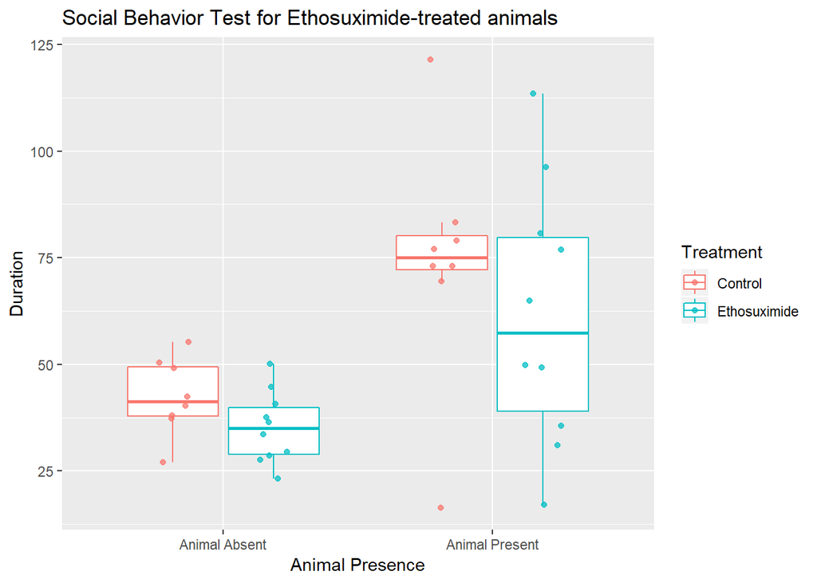

````r
# Compare two paired samples. Use ggpaired() [ggpubr] to create the paired box plot.
# ggpaired(socialData, x = "PresenceStr", y = "DurationNosePoint",
#          color = "Treatment", line.color = "gray", line.size = 0.4,
#          palette = "jco")+
#   stat_compare_means(paired = TRUE)
#
# ```
# ``` {r, message = FALSE}
# p <- ggpaired(socialData, x = "PresenceStr", y = "DurationNosePoint",
#           color = "PresenceStr", palette = "jco",
#           line.color = "gray", line.size = 0.4,
#           facet.by = "Treatment", short.panel.labs = FALSE)
# ```

durationPlot <-
    ggplot(socialData, aes(PresenceStr, DurationNosePoint, color = Treatment)) +
    labs(x = "Animal Presence", y = "Duration",
         title = "Social Behavior Test for Ethosuximide-treated animals")

durationPlot + geom_boxplot(outlier.alpha = 0) +
    geom_point(alpha = 0.75, position = position_jitterdodge(jitter.width = 0.3))
````

```r
# p <- ggplot(socialData, aes(PresenceStr, DurationNosePoint )) +
#   geom_boxplot(aes(color = Treatment)) +
#   scale_color_manual(values = c("#00AFBB", "#E7B800"))
# #p + stat_compare_means(method = "t.test")
# p
```

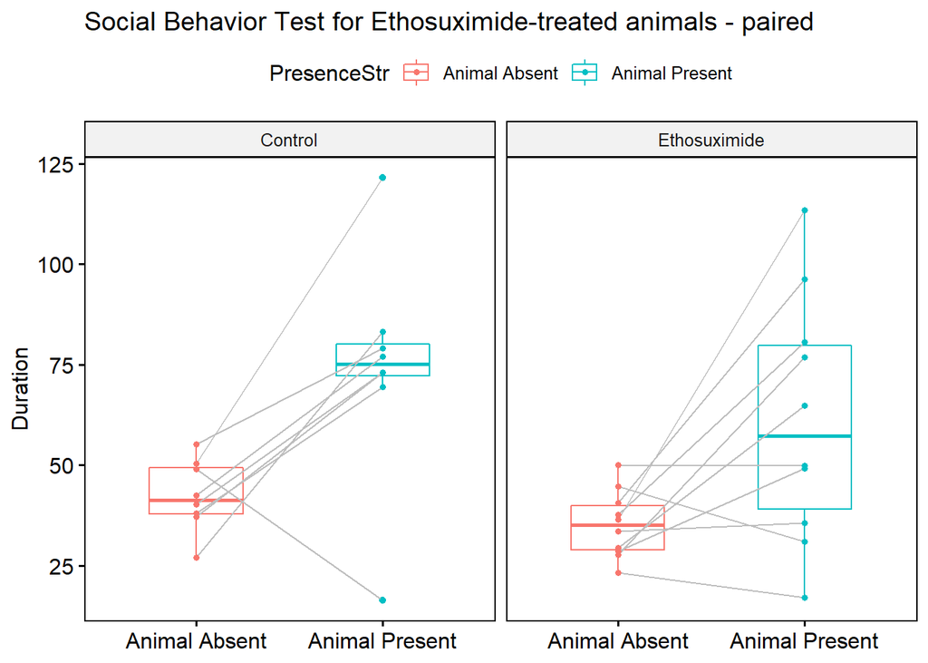

```r
#Pair the data to visualize the change between animal absent or present
ggpaired(socialData, x = "PresenceStr", y = "DurationNosePoint", id = "Tag",
  color = "PresenceStr", fill = "white", palette = "rainbow(6)", width = 0.5,
  point.size = 1.2, line.size = 0.5, line.color = "gray", title = "Social Behavior Test for Ethosuximide-treated animals - paired",
  xlab = FALSE, ylab = "Duration", facet.by = "Treatment")
```

```r
ggsave("social_durationNosePoint_pairedboxplot.png")
```

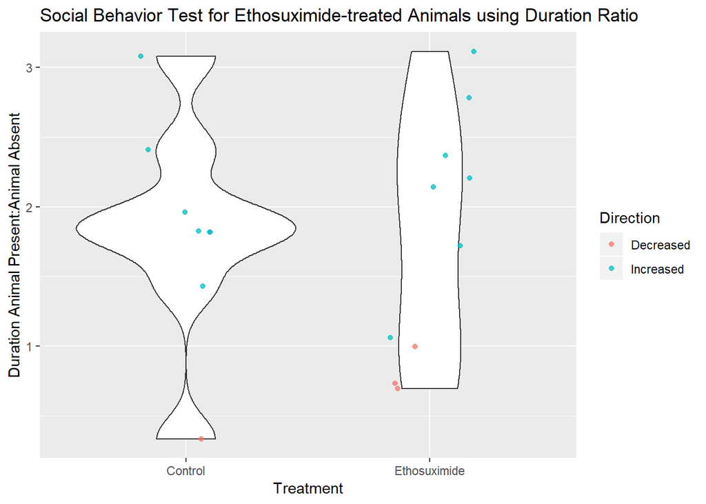

```r
#Pair the data to visualize the change with duration ratio and treatment
durationRatioPlot <-
    ggplot(socialSummarized, aes(TreatmentStr, DurationRatio)) +
           labs(x = "Treatment", y = "Duration Animal Present:Animal Absent",
           title = "Social Behavior Test for Ethosuximide-treated Animals using Duration Ratio")

durationRatioPlot + geom_violin() +
    geom_jitter(aes(color = Direction), alpha = 0.75, width = 0.2)
```

```r
ggsave("social_durationratio_jitter and violin.png")
```

## Perform Statistics

Use the Shapiro-Wilk test to test for normality

```r
# Test the entire data set for normality
shapiro.test(socialData$DurationNosePoint)
```

```
##
##  Shapiro-Wilk normality test
##
## data:  socialData$DurationNosePoint
## W = 0.92239, p-value = 0.01481
```

```r
# Test each data set for normality
tapply(socialData$DurationNosePoint, socialData$Treatment, shapiro.test)
```

```
## $Control
##
##  Shapiro-Wilk normality test
##
## data:  X[[i]]
## W = 0.95101, p-value = 0.5058
##
##
## $Ethosuximide
##
##  Shapiro-Wilk normality test
##
## data:  X[[i]]
## W = 0.87207, p-value = 0.01278
```

Therefore, we apply the Wilcoxon rank-sum test (Mann-Whitney U test) to test for any significant difference between treatment groups.

```r
# Apply the Wilcoxon rank-sum test (Mann-Whitney U test)
wTestResult <-
    wilcox.test(DurationNosePoint ~ Treatment, data = socialData)
wTestResult
```

```
##
##  Wilcoxon rank sum test
##
## data:  DurationNosePoint by Treatment
## W = 204, p-value = 0.1681
## alternative hypothesis: true location shift is not equal to 0
```

Since the p value > 0.05, there isn’t any significant difference between treatment groups.

Test for Variance

```r
var.test(DurationRatio ~ TreatmentStr, socialSummarized,
         alternative = "two.sided")
```

```
##
##  F test to compare two variances
##
## data:  DurationRatio by TreatmentStr
## F = 0.80863, num df = 7, denom df = 9, p-value = 0.7971
## alternative hypothesis: true ratio of variances is not equal to 1
## 95 percent confidence interval:
##  0.1926667 3.9002029
## sample estimates:
## ratio of variances
##           0.808631
```

## Ratio Statistics

```r
# Test the entire data set for normality
shapiro.test(socialSummarized$DurationRatio)
```

```
##
##  Shapiro-Wilk normality test
##
## data:  socialSummarized$DurationRatio
## W = 0.96626, p-value = 0.7252
```

```r
# Test each data set for normality
tapply(socialSummarized$DurationRatio, socialSummarized$TreatmentStr, shapiro.test)
```

```
## $Control
##
##  Shapiro-Wilk normality test
##
## data:  X[[i]]
## W = 0.92483, p-value = 0.4703
##
##
## $Ethosuximide
##
##  Shapiro-Wilk normality test
##
## data:  X[[i]]
## W = 0.92204, p-value = 0.3743
```

Since the p-values are greater than 0.05, the data sets can be considered normally distributed.

Therefore, we apply the Welch Two Sample t-test to test for any significant difference between treatment groups.

```r
# Apply the Welch Two Sample t-test
tTestResult <-
    t.test(DurationRatio ~ TreatmentStr, data = socialSummarized)
tTestResult
```

```
##
##  Welch Two Sample t-test
##
## data:  DurationRatio by TreatmentStr
## t = 0.13465, df = 15.728, p-value = 0.8946
## alternative hypothesis: true difference in means is not equal to 0
## 95 percent confidence interval:
##  -0.7783275  0.8837478
## sample estimates:
##      mean in group Control mean in group Ethosuximide
##                   1.834588                   1.781878
```

Since the p value is greater than 0.05, there isn’t any significant difference between treatment groups.

## Conclusion

There is no significant difference between social interaction between the two treatment groups

```r
#Old Code
# Select duration of animal presence or absence
# animalPresent <-
#       socialData$DurationNosePoint~PresenceStr
#
# collist <- c("PresenceStr")
# sel <-apply(socialData[,collist],1,function(row) "Animal Present" %in% row)
#
# filteredPresent <- socialData[sel,]
# filteredPresent
#
# # animalPresent <- socialData %>% pull(DurationNosePoint.filteredPresent)
# # %>% filter(DurationNosePoint, PresenceStr == "Animal Present")
#
#
# # Take a look at the data with rows filter
# animalPresent
#
# # Select duration of animalabsence
# animalAbsent <-
#      socialData %>% select(DurationNosePoint, "Animal Presence" = 0)
#
# # Take a look at the data with rows filter
# animalAbsent
#
# socialData %>%
#     mutate(DurationPresenceRatio = animalAbsent / animalPresent)
#
# animalAbsent/animalPresent
```